# Exploring the BRFSS data

## Setup

### Load packages

```r
library(ggplot2)
library(dplyr)
```

### Load data

```r
load("brfss2013.RData")
```

## Part 1: Data

The Behavioral Risk Factor Surveillance System (BRFSS) is a US health Survey that looks at behavioral risk factors. The survey is administred by phone and cellular phone. This survey is conducted in 50 US States plus the District of Columbia, Guam, Puerto Rico, and the U.S. Virgin Island.s

### Generalizability

The BRFSS survey could be generalizable to the same population than the sample : US citizen having more than 18 years old, who live in a private residence or college housing only, in the same states as the survey.  
By conducting the surveys by cellular phone in addition to “landline” phones, the survey should be much more representating and therefore generalizable.  
However, some part of the population will be excluded (without phone, or with private numbers).  
Also, the exact time of the phone call is subject to give more weight to a specific population (if the survey is only done during business hours, people working at this time won’t answer) and therefore lead a generalization might not be accurate.  
Random sampling seems to be used, but because it might not cover equaly all the population, one should be careful when doing conclusion and generalization on this survey

### causality

Of course correlation doesn’t mean causality. Only an expert in a given field could analyze all the parameters and say if the causality is likely to exists. Many differents things can explain causality : random (see http://www.tylervigen.com/), external parameter influencing etc. Without a very good knowledge of the subject, it’s quite hasardious to make any causality, even though a few seem obvious.

## Part 2: Research questions

**Research quesion 1:**

Does the sleep time `sleptim1` follow a normal distribution ? If the population is say split in 2 different groups (sleeping a lot, sleeping a few), this could help to study this and try to find correlation that could explain the scheme.

**Research quesion 2:**

Does the income level `income2` play a role to the way people eat dark green vegetables `fvbeans` and orange `fvorang` colored vegetables ?

**Research quesion 3:**

Can we find a relation between the number of vegetables consumed ber day `_vegesum` and cancer `chcscncr` and `chcocncr`. This could follow the idea that the consumtion of vegetable could help in cancer prevention.

## Part 3: Exploratory data analysis

**Research quesion 1:** Does the sleep time `sleptim1` follow a normal distribution ? First we clean the data, remove the NA and display some information about the data

```r
brfss2013$sleptim1[brfss2013$sleptim1>20] = NA
clean_brfss2013_sleep = brfss2013[!(is.na(brfss2013$sleptim1)),]
summary(clean_brfss2013_sleep$sleptim1)
```

```
##    Min. 1st Qu.  Median    Mean 3rd Qu.    Max.
##   0.000   6.000   7.000   7.049   8.000  20.000
```

To speedup the process we only use a sample population of 10 000

```r
sleep_sample <- clean_brfss2013_sleep[sample(1:nrow(clean_brfss2013_sleep), 10000, replace=FALSE),]
```

Trace the histogram

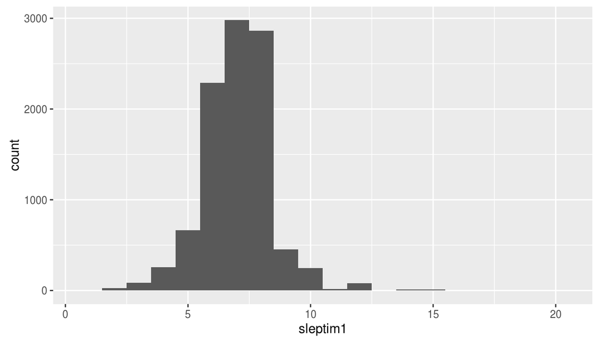

```r
ggplot(data = sleep_sample, aes(x = sleptim1)) +  geom_histogram(binwidth = 1)
```

The population seems to be normal but skewed. Let’s trace the normal q-q graph

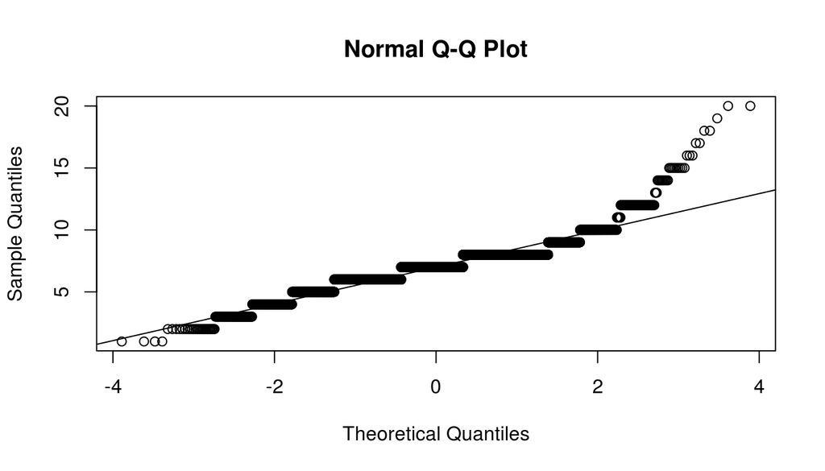

```r
qqnorm(sleep_sample$sleptim1)
qqline(sleep_sample$sleptim1)
```

**Research quesion 2:** Does the income level `income2` play a role to the way people eat dark green vegetables `fvbeans` and orange `fvorang` colored vegetables ?

First we clean all the data

```r
clean_brfss2013_veg = brfss2013[!(is.na(brfss2013$fvbeans)) & !(is.na(brfss2013$fvorang)) & !(is.na(brfss2013$income2)),]
clean_brfss2013_veg$total_veg = clean_brfss2013_veg$fvbeans + clean_brfss2013_veg$fvorang
```

Then we create income categories

```r
unique(clean_brfss2013_veg$income2)
```

```
## [1] Less than $75,000 $75,000 or more   Less than $50,000 Less than $25,000
## [5] Less than $10,000 Less than $20,000 Less than $35,000 Less than $15,000
## 8 Levels: Less than $10,000 Less than $15,000 ... $75,000 or more
```

```r
clean_brfss2013_veg$income_cat[clean_brfss2013_veg$income2 == 'Less than $10,000'] = 0
clean_brfss2013_veg$income_cat[clean_brfss2013_veg$income2 == 'Less than $15,000'] = 1
clean_brfss2013_veg$income_cat[clean_brfss2013_veg$income2 == 'Less than $20,000'] = 2
clean_brfss2013_veg$income_cat[clean_brfss2013_veg$income2 == 'Less than $25,000'] = 3
clean_brfss2013_veg$income_cat[clean_brfss2013_veg$income2 == 'Less than $35,000'] = 4
clean_brfss2013_veg$income_cat[clean_brfss2013_veg$income2 == 'Less than $40,000'] = 5
clean_brfss2013_veg$income_cat[clean_brfss2013_veg$income2 == 'Less than $45,000'] = 6
clean_brfss2013_veg$income_cat[clean_brfss2013_veg$income2 == 'Less than $50,000'] = 7
clean_brfss2013_veg$income_cat[clean_brfss2013_veg$income2 == 'Less than $55,000'] = 8
clean_brfss2013_veg$income_cat[clean_brfss2013_veg$income2 == 'Less than $60,000'] = 9
clean_brfss2013_veg$income_cat[clean_brfss2013_veg$income2 == 'Less than $65,000'] = 10
clean_brfss2013_veg$income_cat[clean_brfss2013_veg$income2 == 'Less than $70,000'] = 11
clean_brfss2013_veg$income_cat[clean_brfss2013_veg$income2 == 'Less than $75,000'] = 12
clean_brfss2013_veg$income_cat[clean_brfss2013_veg$income2 == '$75,000 or more'] = 13
unique(clean_brfss2013_veg$income_cat)
```

```
## [1] 12 13  7  3  0  2  4  1
```

Drawn the boxplot from the categories

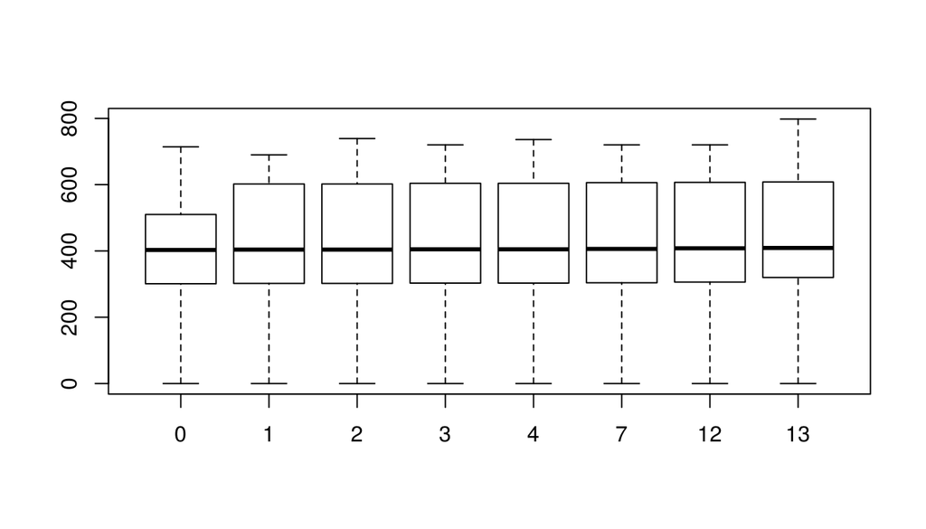

```r
boxplot(clean_brfss2013_veg$total_veg ~ clean_brfss2013_veg$income_cat, ann=F)
```

Let’s take a sample to speedup process

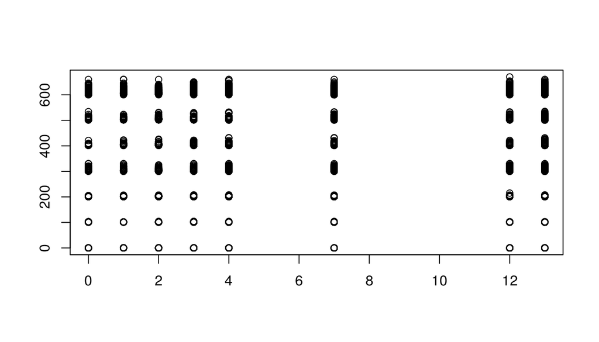

```r
veg_sample <- clean_brfss2013_veg[sample(1:nrow(clean_brfss2013_veg), 10000, replace=FALSE),]

plot(veg_sample$income_cat, veg_sample$total_veg, ann=F)
```

No really readable, we’re going to work on the mean and median of each category

```r
fruit_mean = c()
fruit_median= c()
for ( i in 0:12) {
  fruit_mean[i]=mean(veg_sample$total_veg[veg_sample$income_cat == i])
  fruit_median[i]=median(veg_sample$total_veg[veg_sample$income_cat == i])
}
```

We plot the mean and median of the black and orange fruit consumption

[figure not shown]

```r
plot(fruit_median,col="red", xlab="black and orange fruit consumption median",ylab="income category")
```

[figure not shown]

```r
plot(fruit_mean,col="blue", xlab="black and orange fruit consumption mean",ylab="income category")
```

It seems to have a correlation between black and orange fruit consumption and the income category : the higher the income is, the more fruit is consumed.

**Research quesion 3:** Can we find a relation between the number of vegetables consumed ber day `_vegesum` and cancer `chcscncr` and `chcocncr`. This could follow the idea that the consumtion of vegetable could help in cancer prevention.

First we clean all the data and sum the informations

```r
clean_brfss2013_cancer = brfss2013[!(is.na(brfss2013$fvbeans)) & !(is.na(brfss2013$fvgreen)) & !(is.na(brfss2013$vegetab1)) & !(is.na(brfss2013$chcocncr)) & !(is.na(brfss2013$chcscncr)) & !(is.na(brfss2013$fvorang)),]
clean_brfss2013_cancer$total_veg = clean_brfss2013_cancer$fvbeans + clean_brfss2013_cancer$fvorang + clean_brfss2013_cancer$fvgreen + clean_brfss2013_cancer$vegetab1
clean_brfss2013_cancer$cancer = 0
unique(clean_brfss2013_cancer$chcocncr)
```

```
## [1] No  Yes
## Levels: Yes No
```

```r
clean_brfss2013_cancer$cancer[clean_brfss2013_cancer$chcocncr == 'Yes'] = 1
clean_brfss2013_cancer$cancer[clean_brfss2013_cancer$chcscncr == 'Yes'] = 1
```

Take a sample to plot

```r
cancer_sample <- clean_brfss2013_cancer[sample(1:nrow(clean_brfss2013_cancer), 50000, replace=FALSE),]
```

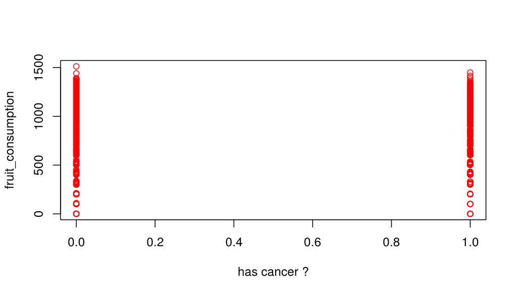

```r
plot(cancer_sample$cancer, cancer_sample$total_veg,col="red", xlab="has cancer ?",ylab="fruit_consumption")
```

Not very readable, let’s trace the histogram of cancer vs non-cancer for better visualization

[figure not shown]

```r
cancer_sample_yes = subset(cancer_sample, cancer == 1)
cancer_sample_no = subset(cancer_sample, cancer == 0)
ggplot(data = cancer_sample_yes, aes(x = total_veg)) +  geom_histogram(binwidth = 1) +
labs(title = paste("Cancer fruit consumption, mean=",round(mean(cancer_sample_yes$total_veg)))) +
ylab("fruit consumption") +
xlab("number of detected cancer")
```

[figure not shown]

```r
ggplot(data = cancer_sample_no, aes(x = total_veg)) +  geom_histogram(binwidth = 1) +
labs(title = paste("Without cancer fruit consumption, mean=",round(mean(cancer_sample_no$total_veg)))) +
ylab("fruit consumption") +
xlab("number of person")
```

As we can see, the repartition looks very similar between the people having cancer vs no cancer. Therefore it’s hard to find any correlation. Means are very similar.